# C++ array library: xtensor

Yung-Yu Chen

PyHUG June 2019

## What is xtensor

- https://xtensor.readthedocs.io/
- “xtensor is a C++ library meant for numerical analysis with multi-dimensional array expressions.”
- Why? Help to deal with multi-dimensional array, which is hard.

# Multi-dimensional arrays in Python

numpy N-dimensional array (ndarry) makes life very easy.

```python
arr = np.zeros((2,3), dtype='float64')
print(arr)
```

```
[[0. 0. 0.]
 [0. 0. 0.]]
```

```python
print(type(arr))
```

```
<class 'numpy.ndarray'>
```

For example, see how easy it is to transpose:

```python
mat = np.arange(9, dtype='float64').reshape((3,3))
print(mat)
```

```
[[0. 1. 2.]
 [3. 4. 5.]
 [6. 7. 8.]]
```

```python
print(mat.T)
```

```
[[0. 3. 6.]
 [1. 4. 7.]
 [2. 5. 8.]]
```

# What's wrong with Python and numpy?

It's usually slow when the problem becomes complex.

This will be demonstrated using a boundary value problem with the Laplace equation for temperature distribution in a $1\times1$ square area.

\begin{align} & \frac{\partial^2 u}{\partial x^2} + \frac{\partial^2 u}{\partial y^2} = 0 \quad (0<x<1; 0<y<1) \\ & u(0,y) = 0, \, u(1,y) = \sin(\pi y) \quad (0<y<1) \\ & u(x,0) = u(x,1) = 0 \quad (0<x<1) \end{align}

Make the grid.

```python
def make_grid():
    nx = 51
    x = np.linspace(0, 1, nx)
    gx, gy = np.meshgrid(x, x)
    u = np.zeros_like(gx)
    u[0,:] = 0
    u[-1,:] = 1 * np.sin(np.linspace(0,np.pi,nx))
    u[:,0] = 0
    u[:,-1] = 0
    return nx, x, u
```

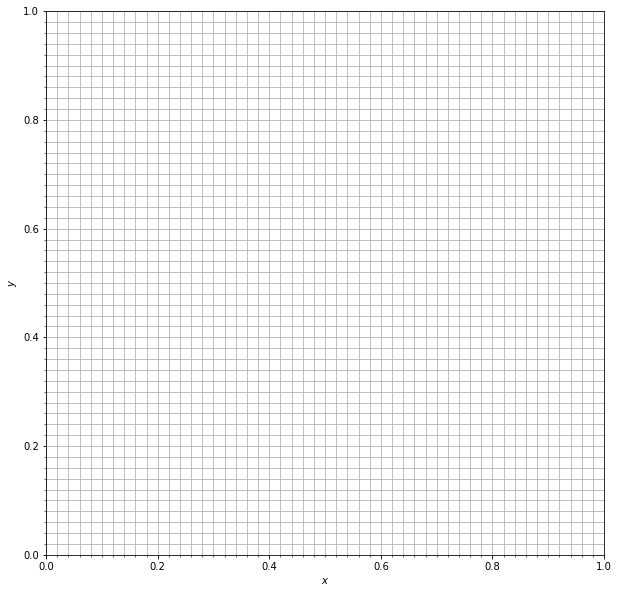

```python
nx, x, uoriginal = make_grid(); show_grid(10)
```

Use the Taylor series expansion to obtain the difference equation:

\begin{align} & \frac{u(x_{i+1}, y_j) - 2u(x_i, y_j) + u(x_{i-1}, y_j)}{(\Delta x)^2} \\ &\quad + \frac{u(x_i, y_{j+1}) - 2u(x_i, y_j) + u(x_i, y_{j+1})}{(\Delta y)^2} = 0 \end{align}

Now we can use the point-Jacobi method to write a formula to iteratively solve the difference equaion:

\begin{align} u^{n+1}(x_i, y_i) = \frac{u^n(x_{i+1}, y_j) + u^n(x_{i-1}, y_j) + u^n(x_i, y_{j+1}) + u^n(x_i, y_{j-1})}{4} \end{align}

The most straight-forward solver implementation in Python is a nested loop:

```python
def solve_python_loop():
    u = uoriginal.copy()
    un = u.copy()
    converged = False
    step = 0
    while not converged:
        step += 1
        for it in range(1, nx-1):
            for jt in range(1, nx-1):
                un[it,jt] = (u[it+1,jt] + u[it-1,jt] + u[it,jt+1] + u[it,jt-1]) / 4
        norm = np.abs(un-u).max()
        u[...] = un[...]
        converged = True if norm < 1.e-5 else False
    return u, step, norm
```

```python
%%time
u, step, norm = solve_python_loop()
```

```
CPU times: user 4.93 s, sys: 7.09 ms, total: 4.94 s
Wall time: 4.94 s
```

```python
show_result(u, step, norm)
```

```
step 2097 norm 9.997406535677822e-06
```

# Array-based code with numpy

There is a cure for the slow runtime: use array to delegate the calculation in C.

```python
def solve_array():
    u = uoriginal.copy()
    un = u.copy()
    converged = False
    step = 0
    while not converged:
        step += 1
        un[1:nx-1,1:nx-1] = (u[2:nx,1:nx-1] + u[0:nx-2,1:nx-1] +
                             u[1:nx-1,2:nx] + u[1:nx-1,0:nx-2]) / 4
        norm = np.abs(un-u).max()
        u[...] = un[...]
        converged = True if norm < 1.e-5 else False
    return u, step, norm
```

```python
%%time
u, step, norm = solve_array()
```

```
CPU times: user 63.4 ms, sys: 1.55 ms, total: 65 ms
Wall time: 64.4 ms
```

```python
assert (u == ugolden).all(); show_result(u, step, norm)
```

```
step 2097 norm 9.997406535677822e-06
```

# Nested loop in C++

Is that fast enough? No, because we haven't seen the speed of C++.

```
const size_t nx = u.shape(0);
xt::xarray<double> un = u;
bool converged = false;
size_t step = 0;
double norm;
while (!converged) {
    ++step;
    for (size_t it=1; it<nx-1; ++it) {
        for (size_t jt=1; jt<nx-1; ++jt) {
            un(it,jt) = (u(it+1,jt) + u(it-1,jt) +
                         u(it,jt+1) + u(it,jt-1)) / 4;
        }
    }
    norm = xt::amax(xt::abs(un-u))();
    if (norm < 1.e-5) { converged = true; }
    u = un;
}
```

And it's not the convoluted array code. The nested loop is closer to the iterative formula.

```python
%%time
u, step, norm = solve_cpp(uoriginal)
```

```
CPU times: user 26.2 ms, sys: 590 µs, total: 26.8 ms
Wall time: 26.7 ms
```

```python
assert (u == ugolden).all(); show_result(u, step, norm)
```

```
step 2097 norm 9.997406535677822e-06
```

# Array-based code in C++

We can also write array code with xtensor:

```
const size_t nx = u.shape(0);
xt::xarray<double> un = u;
auto uxlower = xt::view(u, xt::range(0, nx-2), xt::range(1, nx-1));
auto uxupper = xt::view(u, xt::range(2, nx), xt::range(1, nx-1));
auto uylower = xt::view(u, xt::range(1, nx-1), xt::range(0, nx-2));
auto uyupper = xt::view(u, xt::range(1, nx-1), xt::range(2, nx));
auto uncenter = xt::view(un, xt::range(1, nx-1), xt::range(1, nx-1));
bool converged = false;
size_t step = 0;
double norm;
while (!converged) {
    ++step;
    uncenter = (uxupper + uxlower + uyupper + uylower) / 4;
    norm = xt::amax(xt::abs(un-u))();
    if (norm < 1.e-5) { converged = true; }
    u = un;
}
```

```python
%%time
u, step, norm = solve_cpp_array(uoriginal)
```

```
CPU times: user 72.8 ms, sys: 870 µs, total: 73.6 ms
Wall time: 73.8 ms
```

```python
assert (u == ugolden).all(); show_result(u, step, norm)
```

```
step 2097 norm 9.997406535677822e-06
```

References:

- xtensor; multi-dimensional arrays with broadcasting and lazy computing: https://xtensor.readthedocs.io
- xtensor-python; Python bindings for the xtensor C++ multi-dimensional array library: https://xtensor-python.readthedocs.io
- pybind11 — Seamless operability between C++11 and Python: https://pybind11.readthedocs.io/en/stable/
- IPython / Jupyter integration for pybind11: https://github.com/aldanor/ipybind